# Executive summary

## Goal

In this notebook, we will build various features for demand prediction. The features are roughly categorized as:

- product-based feats
- price-based feats
- competition feats
- time-based feats

**Note:** As this is just a prototype, we will only work with samples of data (as groups) as the whole data, especially **snapshot table**, is gigantic. Each group is defined by three factors (sub-category, gender, season).

## Impediments & current solutions

- Table of daily product snapshots is gigantic, cannot fit into memory --> extract only data of groups
- Certain column names are confusing, e.g., 'id_simple_product' vs. 'sku_simple' --> clarified
- Some un-sync between GFG datalake and venture's DWH (Zalora) --> use only data from datalake
- Changes in Zalora's DWH from old to new Redshift instance (Pitbull) --> checked with Shahbaaz.

## Resulting feature matrix

With regard to these impediments, I built feature matrix for the group of *female skirts in autumn-winter season*. Below is how the matrix look like (first 5 rows)

```python
X.head()
```

|  | sku_config | color_pop | snapshot_date | current_price | discount_from_rrp | n_competitor | rel_price_in_percent | brand_name | brand_total_views | brand_mean_views |
| --- | --- | --- | --- | --- | --- | --- | --- | --- | --- | --- |
| 0 | 006FAAAAB5D8D2GS | 8.013311 | 2016-09-24 | 29.9 | 0.0 | 481 | 0.119624 | zalora | 117430 | 23.776068 |
| 1 | 006FAAAAB5D8D2GS | 8.013311 | 2016-09-25 | 29.9 | 0.0 | 482 | 0.119525 | zalora | 123734 | 25.032167 |
| 2 | 006FAAAAB5D8D2GS | 8.013311 | 2016-09-26 | 29.9 | 0.0 | 499 | 0.116941 | zalora | 109648 | 22.119831 |
| 3 | 006FAAAAB5D8D2GS | 8.013311 | 2016-09-27 | 29.9 | 0.0 | 515 | 0.113703 | zalora | 117609 | 23.706712 |
| 4 | 006FAAAAB5D8D2GS | 8.013311 | 2016-09-28 | 29.9 | 0.0 | 505 | 0.115529 | zalora | 109389 | 22.215475 |

We now go into details including:

- What are the features?
- How we define and calculate the features?

# Initialization

- Load standard modules, our own modules **feat_engineer** for feature engineering
- Load data of group 1 ('skirts', 'female', 'autumn-winter')

```python
import pandas as pd
import numpy as np
import matplotlib.pyplot as pl
import feat_engineer as feat_engineer; from feat_engineer import *

from importlib import reload
```

```python
CLEAN_DIR = '/Users/gfg/data/venture=Zalora/sg/clean/'
```

```python
df_all = pd.read_csv(CLEAN_DIR + 'data_all.csv')
```

```python
n_config = df_all.id_config_product.nunique()
print('# configs in data: {}'.format(n_config))
```

```
# configs in data: 159348
```

```python
# Load sample data of a group ('skirts', 'female', 'autumn-winter')
g1_df = pd.read_csv(CLEAN_DIR + 'skirt_fem_aw.csv', parse_dates=['snapshot_date'])
print(g1_df.shape)
```

```
(747178, 36)
```

#### Reload to sync with script

```python
reload(feat_engineer); from feat_engineer import *
```

# Product-based features

These include:

- Color popularity
- Size popularity
- Brand popularity

## Color popularity

This measures how much a color is popular among customers. It is natural that popularity of colors will **vary with category** (sub-cat in our case). For example, we expect that for kids apparel, joyful colors like red, pink, yellow are preferred; while for shirts, colors like white, blue are preferred. Thus, we should compute color popularity for each sub-cat. Moreover, we expect that color popularity will NOT change with time (it may change from year to year but not within one year). In short, color popularity only depends on **color and sub-cat.**

```python
sub_cats = df_all.sub_cat.sort_values().unique()
```

[output not shown]

### Def

Popularity of a color $c$ under a sub-cat $k$ is the following ratio: $$ pop(c, k) = \dfrac{n(c, k)}{\sum_c^\prime n(c^\prime, k)} $$ where $n(c, k)$ is the number of sold units which are under sub-cat $k$ and of color $c$.

### Computation

```python
frames = [color_pop(sc, df_all) for sc in sub_cats]
by_cat_color = pd.concat(frames)
by_cat_color.to_csv(CLEAN_DIR + 'sales_by_cat_color.csv', index=False)
```

```python
# add color popularity to each SKU simple in a group
by_cat_color.rename(columns={'percent': 'color_pop'}, inplace=True)
cols = ['color', 'sub_cat', 'n_sold', 'color_pop']
by_cat_color = by_cat_color[cols].sort_values('color')

by_cat_color.sub_cat = lower_all(by_cat_color.sub_cat)
g1_df = g1_df.merge(by_cat_color[['color', 'sub_cat', 'color_pop']])
```

## Size popularity

### Defs

#### Popularity of a size

Given size $s$, its popularity under sub-cat $k$ is: $$ pop(s, k) = \dfrac{m(s, k)}{\sum_s^\prime m(s^\prime, k)} $$ where $m(s, k)$ is the number of sold units which are under sub-cat $k$ and of size $s$.

#### Size popularity of a config

Given a config $cf$ under sub-cat $k$, its size popularity will be the weighted average of its sizes' popularity: $$ pop_{size}(cf, k) = \sum_{s \in S_{cf}} w_s * pop(s, k) $$

where

- $S_{cf}$ is the set of sizes of the config
- $ w_s = \frac{n(cf, s)}{\sum_{s^\prime \in S_{cf}} n(cf, s^\prime)} $ is the weight of size $s$

A challenge when working with sizes is that they are not normalized yet. We have all kinds of sizes, as shown below. Thus, we first need a mapping to normalize sizes.

```python
df_all['size_name'].value_counts()
```

```
S           529049
M           511393
One Size    384277
L           287937
XS          158431
XL          114322
38           87502
37           76678
8            74245
10           64183
39           61393
One size     61316
36           54078
6            49603
40           49442
41           37508
12           37481
14           24226
42           23519
43           19168
7            17900
35           15553
9            14131
44           12326
30           11512
16           11290
32           10914
5             9761
34            9462
45            6772
             ...
16S              1
85G              1
18 mm            1
W2632            1
85E              1
12.5             1
90D              1
W2532            1
85A              1
3Y               1
W2628            1
26/28            1
85 ml            1
50 g             1
2Y               1
W3234            1
14L              1
XS/L32           1
W3130            1
43-44            1
XL/L32           1
7Y               1
10DD             1
18-24M           1
23/25            1
0.5              1
21               1
L/L34            1
54 mm            1
25 ml            1
Name: size_name, Length: 426, dtype: int64
```

### Computation

```python
frames = [size_pop(sc, df_all) for sc in sub_cats]
size_pop_by_cat = pd.concat(frames)
size_pop_by_cat.to_csv(CLEAN_DIR + 'size_pop_by_cat.csv', index=False)
```

## Brand popularity

**Note**: Currently brand popularity is assumed to be independent of categ.

**Q:** Should brand popularity vary with the categ, i.e., a brand can be popular under one cat, but not popular in another cat?

**A**:

### Via page views

Page view score of a brand $b$ at a given date $d$ can be aggregated page views of configs under $b$ at date $d$. The aggregation can be via:

- sum
- mean

This feature is obviously depend on date.

##### Merge `view_df` with `df_all` to join brands with views of their configs

The merging is expected to create NAs in brand names.

**Reason:** some configs from 2016 may not be kept in product table anymore (?)

```python
cols = ['id_config_product', 'brand_name', 'brand_type', 'brand_identifier']
tmp = df_all[cols].drop_duplicates()
```

```python
view_df = view_df.dropna()
view_df.rename(columns={'days': 'date'}, inplace=True)
view_df = pd.merge(view_df, tmp, how='left')
```

```python
view_df.head()
```

#### Daily views of brands

```python
# mean views
mean_views = view_df.groupby(['brand_name', 'date']).agg({'views': np.mean, 'impressions': np.mean})
mean_views = mean_views.rename(columns={'views': 'mean_views', 'impressions': 'mean_impressions'}).reset_index()
```

```python
# total views
daily_brand_views = view_df.groupby(['brand_name', 'brand_type', 'date']).agg({'views': sum, 'impressions': sum})
daily_brand_views = daily_brand_views.rename(columns={'views': 'total_views', 'impressions': 'total_impressions'}).reset_index()
daily_brand_views.sort_values('total_views', ascending=False, inplace=True)
```

```python
# merge total views and mean views
daily_brand_views = daily_brand_views.merge(mean_views)
```

```python
# view distribution
daily_brand_views.total_views.describe()
```

```python
local_brands_view = daily_brand_views.query('brand_type == "local_branded"')
region_brands_view = daily_brand_views.query('brand_type == "regional_branded"')
```

```python
region_brands_view.sort_values('total_views', ascending=False).head()
```

```python
region_brands_view.sort_values('mean_views', ascending=False).head()
```

```python
daily_brand_views.to_csv(CLEAN_DIR + '2016_daily_brand_views.csv', index=False)
```

##### Total views by months/season

We want to take into account seasonal factor of fashion products by looking at brand views in diff seasons.

- Monthly views
- Season views

**Note:** Should views be normalized by no. of days?

```python
daily_brand_views['month'] = daily_brand_views['date'].apply(lambda d: d.month)
```

```python
monthly_views = daily_brand_views.groupby(['brand_name', 'brand_type', 'month']).agg({'total_views': sum, 'total_impressions': sum})
monthly_views = monthly_views.reset_index()
```

```python
monthly_views.total_views.describe()
```

#### Dynamics of brand views

```python
def view_ts(brand, view_data):
    sub_df = view_data.query('brand_name == "{}"'.format(brand.lower()))
    return sub_df.sort_values('date')
```

```python
def viz_view_ds(view1_df, view2_df, agg_type='total'):
    fig, axes = pl.subplots(1, 2, figsize=(12, 5))
    col = ['{}_views'.format(agg_type)]
    ylab = ' '.join([agg_type.title(), 'views'])

    pl.subplot(121)
    pl.plot(view1_df[0].date, view1_df[0][col] , 'r',
            view1_df[1].date, view1_df[1][col], 'b',
           view1_df[2].date, view1_df[2][col], 'm')

    pl.legend(local_top3)
    pl.xlabel('Date'); pl.ylabel(ylab)
    pl.title('Local brands')
    pl.grid(True, linestyle='--')

    pl.subplots_adjust(wspace=.4)
    pl.subplot(122)
    pl.plot(view2_df[0].date, view2_df[0][col], 'r',
            view2_df[1].date, view2_df[1][col], 'b',
           view2_df[2].date, view2_df[2][col], 'm')

    pl.legend(region_top3)
    pl.xlabel('Date'); pl.ylabel(ylab)
    pl.title('Region brands')
    pl.grid(True, linestyle='--')

    fig.autofmt_xdate()
    return fig
```

- Local vs. regional brands:

```python
local_brands_view = daily_brand_views.query('brand_type == "local_branded"')
region_brands_view = daily_brand_views.query('brand_type == "regional_branded"')
```

```python
local_brands_view = local_brands_view.sort_values('total_views', ascending=False)
local_brands_view.head()
```

```python
region_brands_view = region_brands_view.sort_values('total_views', ascending=False)
region_brands_view.head(10)
```

```python
local_brands = local_brands_view.brand_name.unique()
local_top3 = local_brands[:3]
print(local_top3)
```

```python
region_brands = region_brands_view.brand_name.unique()
region_top3 = region_brands[:3]
print(region_top3)
```

```python
local_top_views = [view_ts(b, local_brands_view) for b in local_top3]
region_top_views = [view_ts(b, region_brands_view) for b in region_top3]
```

```python
fig = viz_view_ds(local_top_views, region_top_views)
pl.savefig(CLEAN_DIR + 'total_view.pdf')
pl.show(); pl.close()
```

[output not shown]

```python
fig = viz_view_ds(local_top_views, region_top_views, agg_type='mean')
pl.savefig(CLEAN_DIR + 'mean_view.pdf')
pl.show(); pl.close()
```

[output not shown]

```python
%%time
view_df.to_csv(CLEAN_DIR + '2016_daily_config_views.csv', index=False)
```

### Via sell through rate (Alyona)

Given a config $cf$ and a date $d$, its sell through rate $ r(cf, d) $ is defined as the following ratio: $$ r(cf, d) = \dfrac{n(cf, d)}{s_{cf, 0}} $$ where $n(cf, d)$ is the no. of $cf$'s units sold up to date $d$ and $s_{cf, 0}$ is initial stock of $cf$. Both $n(cf, d)$ and $s_{cf, 0}$ should be summed over all simples of the config.

- Initial stocks for SKUs: get from product snapshot table.

```python
# check if each config is activated only once
tmp = df_all.groupby(keys + ['product_name']).agg({'activated_at': 'nunique'})
tmp = tmp.rename(columns={'activated_at': 'n_activate'}).reset_index()
all(tmp.n_activate == 1)
```

```python
# get activation date
by_config = df_all.groupby(keys + ['product_name']).agg({'activated_at': np.unique})
by_config.reset_index(inplace=True)
by_config.sort_values('id_config_product', inplace=True)
```

```python
# Sell thru rate until end of 2016
```

# Price-based features

These include:

- Price of config
- Discount of the price from RRP (in percentage, i.e., (black_price - red_price)/black_price).

Config prices are available from product snapshots. However, we do not work directly with the whole snapshot table as it is too large. Instead we extract data for each group of configs. After querying prices, we only need to compute discount.

First, we check which price data are currently available. We can see below that there are 4 price attributes: _permanent_markdown_price, price, special*price* and _current*price*. Double-check shows that *price* is black price and _current*price* is red price. So we can compute the discount from them.

```python
price_cols = [c for c in g1_df.columns if 'price' in c]
price_cols
```

```
['fk_original_price_band',
 'fk_current_price_band',
 'permanent_markdown_price',
 'price',
 'special_price',
 'current_price']
```

```python
# merge certain attribs to group data
cols = ['fk_simple_product', 'product_name', 'brand_name', 'season', 'gender', 'sub_cat', 'color']
g1_df = pd.merge(g1_df, df_all[cols].drop_duplicates(), how='left')
g1_df.shape
```

```
(747178, 41)
```

```python
g1_df.columns
```

[output not shown]

## Discount from RRP

In percentage

```python
g1_df['discount'] = 100*(g1_df.price - g1_df.current_price)/g1_df.price
```

```python
g1_df = g1_df.sort_values(['sku_config', 'snapshot_date'])
```

### Analyze discount of some brands for sanity check

- Mango

```python
mango_cf = g1_df.query('brand_name == "mango"').sku_config.unique()
mango_cf[:5]
```

```
array(['MA022AA15LNOSG', 'MA022AA19LBGSG', 'MA022AA50JYVSG',
       'MA022AA52HVBSG', 'MA022AA53HVASG'], dtype=object)
```

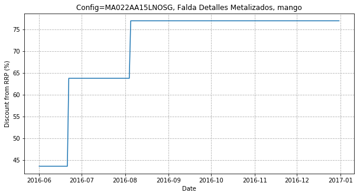

```python
viz_discount_ts(sku_config='MA022AA15LNOSG', price_df=g1_df, plot_dir=CLEAN_DIR)
```

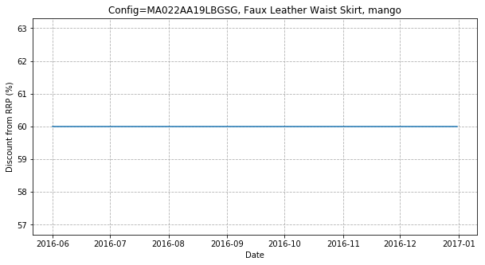

```python
viz_discount_ts(sku_config='MA022AA19LBGSG', price_df=g1_df, plot_dir=CLEAN_DIR)
```

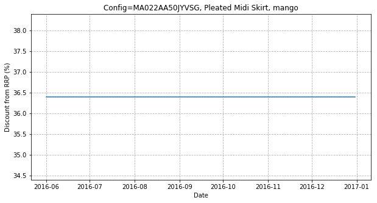

```python
viz_discount_ts(sku_config='MA022AA50JYVSG', price_df=g1_df, plot_dir=CLEAN_DIR)
```

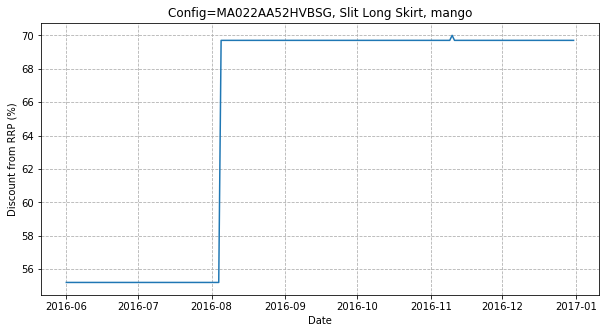

```python
viz_discount_ts(sku_config='MA022AA52HVBSG', price_df=g1_df, plot_dir=CLEAN_DIR)
```

```python
out_df = df_all
```

```python
# get sub_sale from storage
%store -r sub_sale
```

```python
cols = ['id_simple_product', 'activated_at']
active_df = sub_sale[cols].drop_duplicates()
active_df.sort_values(cols, inplace=True)
```

```python
active_df.head()
```

```python
df_all = df_all.merge(active_df)
print(df_all.shape)
```

```python
df_all.to_csv(CLEAN_DIR + 'data_all.csv', index=False)
```

```python
print(df_all.columns)
```

```python
cols = ['id_config_product', 'product_name', 'activated_at', 'is_visible']
non_visibles = df_all[df_all.is_visible == 0][cols]
non_visibles.head()
```

- Zalora

```python
zalora_cf = g1_df.query('brand_name == "zalora"').sku_config.unique()
zalora_cf[:3]
```

```
array(['006FAAAAB5D8D2GS', '06FCAAA0C4CDF1GS', '15081AACDC617AGS'], dtype=object)
```

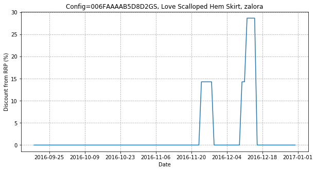

```python
viz_discount_ts(sku_config='006FAAAAB5D8D2GS', price_df=g1_df, plot_dir=CLEAN_DIR)
```

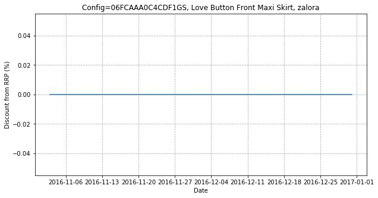

```python
viz_discount_ts(sku_config='06FCAAA0C4CDF1GS', price_df=g1_df, plot_dir=CLEAN_DIR)
```

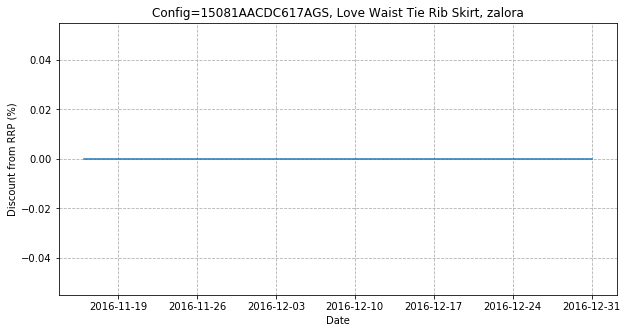

```python
viz_discount_ts(sku_config='15081AACDC617AGS', price_df=g1_df, plot_dir=CLEAN_DIR)
```

# Competition-based features

## No. of competitors

Given a config, its competitors are defined as other configs in the same group (determined by sub-categ, gender, season) which are **visible**. The number of competitors will change over time when configs *entering* or *exiting from* a group (i.e. becomes visible/invisible). Thus, for each visible config $cf$ in group $g$, we define its no. of competitors on date $d$ as: $$ n_c(cf, d) = n_c := n_{viz}(g, d) - 1 $$ where $n_{viz}(g, d)$ is the number of visible configs of group $g$ on date $d$.

```python
df_all.columns
```

```
Index(['id_simple_product', 'item_before_cancellation', 'item_cancelled',
       'ordered_date', 'original_unit_price', 'unit_price', 'paid_price',
       'wrapping_price', 'sales_at_full_price', 'is_sold', 'id_config_product',
       'product_name', 'color', 'size_name', 'brand_type', 'brand_status',
       'brand_name', 'brand_department', 'brand_tier', 'brand_identifier',
       'sub_cat', 'is_visible', 'discount', 'season', 'gender',
       'activated_at'],
      dtype='object')
```

```python
# no. of visible configs by day
def cal_daily_visible(df):
    res = df.query('is_visible == 1').groupby('snapshot_date').agg({'sku_config': 'nunique'})
    res = res.rename(columns={'sku_config': 'n_visible'}).reset_index()
    return res

# plot dynamics of no. of visible configs
def viz_n_visible(df, title=None):
    fig = pl.figure()
    pl.plot(df.snapshot_date, df.n_visible)
    pl.xlabel('Date'); pl.ylabel('No. of (visible) configs')
    pl.grid(True, linestyle='--')
    if title: pl.title(title)
    return fig
```

```python
g1_df.snapshot_date = pd.to_datetime(g1_df.snapshot_date)
```

```python
visible_df = cal_daily_visible(g1_df)
```

```python
# merge to populate n_visible to all configs
g1_df = g1_df.merge(visible_df)
g1_df.shape
```

```
(747178, 43)
```

```python
g1_df['n_competitor'] = g1_df['n_visible'] - 1
```

## Relative price against competitors

Given config $cf$ in group $G$, we define $cf$'s relative price on date $d$ against competing configs as the ratio between $cf$'s price and sum of prices of configs in $G$. $$ rp(cf, G, d) = \dfrac{p(cf, d)}{\sum_{cf^\prime \in G} p(cf^\prime, d)} $$

- Get the slice of **visible** configs of group on date $d$ and calculate relative prices for those configs:

```python
def get_slice(group_df, d):
    cols = ['sku_config', 'snapshot_date', 'price', 'current_price', 'special_price', 'cost_supplier']
    sub_df = group_df.query('snapshot_date == "{}" and is_visible == 1'.format(d))[cols]
    sub_df = sub_df.drop_duplicates() # dups due to simples of the same config
    return sub_df
```

```python
def rel_prices_at_day(d, group_df):
    sub_df = get_slice(group_df, d)
    sub_df['rel_price_in_percent'] = to_percent(sub_df['current_price'])
    return sub_df
```

```python
def cal_rel_prices(group_df):
    days = group_df.snapshot_date.unique()
    print('n_day: {}'.format(len(days)))
    frames = [rel_prices_at_day(d, group_df) for d in days]

    res = pd.concat(frames)
    res.snapshot_date = pd.to_datetime(res.snapshot_date)
    res.sort_values('rel_price_in_percent', ascending=False, inplace=True)
    return res
```

```python
# compute rel prices
rel_price_df = cal_rel_prices(g1_df)
```

```python
rel_price_df.sort_values('rel_price_in_percent', ascending=False, inplace=True)
rel_price_df.sku_config.unique()[:3]
```

[output not shown]

```
array(['MI665AA52VPZMY', 'WA056AA32EDNSG', 'WA653AA82CERMY'], dtype=object)
```

```python
rel_price_df.head()
```

|  | sku_config | snapshot_date | price | current_price | special_price | cost_supplier | rel_price_in_percent |
| --- | --- | --- | --- | --- | --- | --- | --- |
| 504610 | MI665AA52VPZMY | 2016-08-03 | 259.0 | 259.0 | NaN | 406.98 | 1.988936 |
| 209505 | WA056AA32EDNSG | 2016-06-05 | 219.0 | 131.4 | 175.2 | 122.80 | 1.840439 |
| 504622 | MI665AA52VPZMY | 2016-08-06 | 259.0 | 259.0 | NaN | 406.98 | 1.840045 |
| 504626 | MI665AA52VPZMY | 2016-08-07 | 259.0 | 259.0 | NaN | 406.98 | 1.837209 |
| 504618 | MI665AA52VPZMY | 2016-08-05 | 259.0 | 259.0 | NaN | 406.98 | 1.829130 |

### Visualize dynamics of relative price

```python
def grid_on():
    pl.grid(True, linestyle='--')
```

```python
def viz_rel_prices(cf):
    sub_df = res.query('sku_config == "{}"'.format(cf)).sort_values('snapshot_date')
    fig = pl.figure()
    pl.plot(sub_df.snapshot_date, sub_df.rel_price_in_percent)
    pl.xlabel('Date'); pl.ylabel('Relative price against competitors (in %)')
    pl.title('SKU config: {}'.format(cf))
    grid_on()
    pl.savefig(CLEAN_DIR + 'rel_price_{}.pdf'.format(cf))
    return fig
```

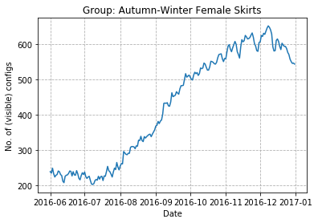

```python
# visualize dynamics of no. of configs in group 1
g1_visible = cal_daily_visible(g1_df)
gname = ' '.join([season, gender, sub_cat])
fig = viz_n_visible(g1_visible, title='Group: {}'.format(gname.title()))
pl.savefig(CLEAN_DIR + '{}.pdf'.format(gname.replace(' ', '_')))
pl.show(); pl.close()
```

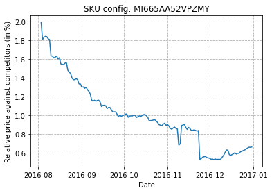

```python
viz_rel_prices(cf='MI665AA52VPZMY')
```

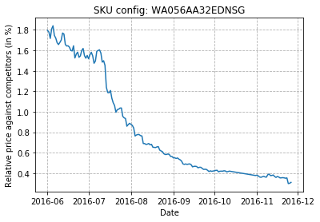

```python
viz_rel_prices(cf='WA056AA32EDNSG')
```

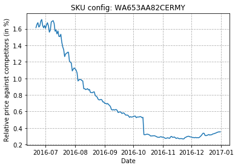

```python
viz_rel_prices(cf='WA653AA82CERMY')
```

# Time features

These include:

- Time to end of season (EoS)
- in_season: an indicator for whether a product is still in its 'correct' season
- is_weekend: indicates whether a date is weekend or weekday
- is_holiday: indicates whether a date is a holiday
- in_grand_sale: indicates whether a date is within grand-sale season (specific to SG)

These features are currently not available yet. The first two are assigned to Alyona but waiting for hard-coded EoS date (from buying team).

# Build feature matrix

```python
cols = ['sku_config', 'color_pop', 'snapshot_date', 'current_price', 'discount', 'n_competitor']
X = g1_df.query('is_visible == 1')[cols].drop_duplicates()
```

```python
print('# rows in X: {}'.format(X.shape[0]))
print('# configs in X: {}'.format(X.sku_config.nunique()))
```

```
# rows in X: 90273
# configs in X: 1103
```

## Add relative price feat

```python
print('# rows in rel_price_df: {}'.format(rel_price_df.shape[0]))
print('# configs in rel_price_df: {}'.format(rel_price_df.sku_config.nunique()))
```

```
# rows in rel_price_df: 90290
# configs in rel_price_df: 1103
```

X and rel_price_df have the same number of configs, so why difference in # rows?

```python
rel_price_df.columns
```

```
Index(['sku_config', 'snapshot_date', 'price', 'current_price',
       'special_price', 'cost_supplier', 'rel_price_in_percent'],
      dtype='object')
```

```python
fixed_rel_prices = rel_price_df[['sku_config', 'snapshot_date', 'rel_price_in_percent']].drop_duplicates()
```

```python
fixed_rel_prices.to_csv(CLEAN_DIR + 'rel_prices_g1.csv', index=False)
```

```python
# align both DFs to prep for appending
X.sort_values(['sku_config', 'snapshot_date'], inplace=True)
fixed_rel_prices.sort_values(['sku_config', 'snapshot_date'], inplace=True)
```

```python
X['rel_price_in_percent'] = fixed_rel_prices['rel_price_in_percent']
```

```python
X.to_csv(CLEAN_DIR + 'g1_feats.csv', index=False)
```

## Add brand popularity

```python
# Load feature matrix built up to now
X = pd.read_csv(CLEAN_DIR + 'g1_feats.csv', parse_dates=['snapshot_date'])
```

```python
X.snapshot_date.dtype
```

```
dtype('<M8[ns]')
```

### Via page views

```python
# add brand info to group 1
key = ['fk_simple_product']
cols = key + ['brand_name', 'brand_type']
brand_df = df_all[cols].drop_duplicates()

g1_df = g1_df.merge(brand_df)
```

```python
g1_df.to_csv(CLEAN_DIR + 'skirt_fem_aw.csv', index=False)
```

```python
g1_df.columns
```

```
Index(['fk_simple_product', 'fx_rate', 'fk_original_price_band',
       'fk_markdown_band', 'fk_current_price_band', 'snapshot_date',
       'inventory_value', 'boost', 'brand_status', 'cost', 'is_visible',
       'stock', 'permanent_markdown_from_date', 'permanent_markdown_price',
       'price', 'sku_config_status', 'sku_simple_status', 'supplier_status',
       'special_cogs', 'special_price', 'special_from_date', 'special_to_date',
       'id_catalog_config', 'sku_simple', 'id_supplier', 'current_price',
       'catalog_type', 'shop_type', 'cost_supplier', 'online_aging',
       'sku_config', 'intake_margin', 'total_stock', 'venture_code',
       'brand_name', 'brand_type'],
      dtype='object')
```

g1_df now contains both snapshot_date and brand, so we can merge page views to it.

```python
# Load brand pop
_16_brand_pop = pd.read_csv(CLEAN_DIR + '2016_daily_brand_views.csv',
                            parse_dates=['date'])

cols = ['brand_name', 'date', 'total_views', 'mean_views']
brand_pop = _16_brand_pop[cols].sort_values(['brand_name', 'date'])
brand_pop.head()
```

|  | brand_name | date | total_views | mean_views |
| --- | --- | --- | --- | --- |
| 152785 | !solid | 2016-01-01 | 39 | 1.147059 |
| 175143 | !solid | 2016-01-02 | 26 | 0.764706 |
| 122847 | !solid | 2016-01-03 | 67 | 1.970588 |
| 150103 | !solid | 2016-01-04 | 41 | 1.171429 |
| 170704 | !solid | 2016-01-05 | 28 | 0.800000 |

```python
# Merge page views to g1_df
left_cols, right_cols = ['brand_name', 'snapshot_date'], ['brand_name', 'date']
cols = ['sku_config'] + left_cols
joined = g1_df[cols].merge(brand_pop, left_on=left_cols, right_on=right_cols)
joined.shape
```

```
(732263, 6)
```

```python
g1_df.shape[0] - joined.shape[0]
```

```
14915
```

No. of rows in joined DF is less than that in g1_df, either some brands or some dates are missing, need to inspect later.

```python
joined.rename(columns={'total_views': 'brand_total_views',
                       'mean_views': 'brand_mean_views'}, inplace=True)
del joined['date']
joined.drop_duplicates(inplace=True)
```

```python
res = X.merge(joined)
```

```python
res.shape[0] - X.shape[0]
```

```
-8
```

```python
X = res; del res
```

```python
X = X.rename(columns={'discount': 'discount_from_rrp'})
X.to_csv(CLEAN_DIR + 'g1_feats.csv', index=False)
```

```python
X.head()
```

|  | sku_config | color_pop | snapshot_date | current_price | discount_from_rrp | n_competitor | rel_price_in_percent | brand_name | brand_total_views | brand_mean_views |
| --- | --- | --- | --- | --- | --- | --- | --- | --- | --- | --- |
| 0 | 006FAAAAB5D8D2GS | 8.013311 | 2016-09-24 | 29.9 | 0.0 | 481 | 0.119624 | zalora | 117430 | 23.776068 |
| 1 | 006FAAAAB5D8D2GS | 8.013311 | 2016-09-25 | 29.9 | 0.0 | 482 | 0.119525 | zalora | 123734 | 25.032167 |
| 2 | 006FAAAAB5D8D2GS | 8.013311 | 2016-09-26 | 29.9 | 0.0 | 499 | 0.116941 | zalora | 109648 | 22.119831 |
| 3 | 006FAAAAB5D8D2GS | 8.013311 | 2016-09-27 | 29.9 | 0.0 | 515 | 0.113703 | zalora | 117609 | 23.706712 |
| 4 | 006FAAAAB5D8D2GS | 8.013311 | 2016-09-28 | 29.9 | 0.0 | 505 | 0.115529 | zalora | 109389 | 22.215475 |